# Bayesian_demo

Yaqian Huang

2023-09-02

## Dataset of voicing of glottal fricatives

### research question: to what extent does voicing intensity differ in voiceless and voiced glottal fricatives at the word-initial position?

```r
df <- read_csv('df.csv')

head(df)
```

```
## # A tibble: 6 × 7
##   Filename       language    dur lartype family        area          norm.soe
##   <chr>          <chr>     <dbl> <chr>   <chr>         <chr>            <dbl>
## 1 20-to_go       A'ingae   168.  h       A'ingae       South America   0.0988
## 2 55-to_go       A'ingae   135.  h       A'ingae       South America   0.172
## 3 014-hang       Afrikaans  86.4 H       Indo-European Africa          0.329
## 4 032-hands      Afrikaans 156.  H       Indo-European Africa          0.207
## 5 148-horizontal Afrikaans  55.9 H       Indo-European Africa          0.499
## 6 158-historian  Afrikaans  20.6 H       Indo-European Africa          0.451
```

## brms model

```r
priors_weak <- c(
  # prior for the Intercept (= the reference level)
  prior(normal(0.2, 1), class = Intercept),
  # prior for the fixed effect coefficient for H
  prior(normal(0.2, .5), class = b, coef = lartypeH),
  # prior for the residual variance for gaussian()
  prior(cauchy(0, 0.1), class = sigma)
)

set.seed(62938)
mod <- brm(formula=norm.soe~dur+lartype+(1|family)+(1|area),data=df,
               family = gaussian(), prior = priors_weak,
               save_pars = save_pars(all = T),
               iter=10000,warmup=2000,
               control = list(adapt_delta = 0.999)) # for higher flexibility & treedepth
```

[output not shown]

### Summarize the model fit

```r
summary(mod)
```

```
##  Family: gaussian
##   Links: mu = identity; sigma = identity
## Formula: norm.soe ~ dur + lartype + (1 | family) + (1 | area)
##    Data: df (Number of observations: 352)
##   Draws: 4 chains, each with iter = 10000; warmup = 2000; thin = 1;
##          total post-warmup draws = 32000
##
## Group-Level Effects:
## ~area (Number of levels: 6)
##               Estimate Est.Error l-95% CI u-95% CI Rhat Bulk_ESS Tail_ESS
## sd(Intercept)     0.06      0.04     0.01     0.16 1.00     7125     8222
##
## ~family (Number of levels: 24)
##               Estimate Est.Error l-95% CI u-95% CI Rhat Bulk_ESS Tail_ESS
## sd(Intercept)     0.06      0.02     0.03     0.11 1.00     8350    10783
##
## Population-Level Effects:
##           Estimate Est.Error l-95% CI u-95% CI Rhat Bulk_ESS Tail_ESS
## Intercept     0.33      0.04     0.25     0.41 1.00    11598    13983
## dur           0.00      0.00    -0.00     0.00 1.00    32079    22291
## lartypeH      0.04      0.03    -0.01     0.09 1.00    29494    25166
##
## Family Specific Parameters:
##       Estimate Est.Error l-95% CI u-95% CI Rhat Bulk_ESS Tail_ESS
## sigma     0.14      0.01     0.13     0.15 1.00    26199    24319
##
## Draws were sampled using sampling(NUTS). For each parameter, Bulk_ESS
## and Tail_ESS are effective sample size measures, and Rhat is the potential
## scale reduction factor on split chains (at convergence, Rhat = 1).
```

Extract samples from fitted model

```r
as_draws_df(mod)
```

```
## # A draws_df: 8000 iterations, 4 chains, and 69 variables
##    b_Intercept    b_dur b_lartypeH sd_area__Intercept sd_family__Intercept
## 1         0.37  1.6e-04     0.0148              0.029                0.064
## 2         0.34  4.7e-04     0.0575              0.028                0.062
## 3         0.31  6.0e-04    -0.0071              0.043                0.068
## 4         0.40 -2.4e-04     0.0877              0.028                0.051
## 5         0.36 -6.4e-05    -0.0182              0.044                0.092
## 6         0.35  1.6e-04    -0.0299              0.062                0.095
## 7         0.33  3.7e-04     0.0323              0.040                0.063
## 8         0.30  2.3e-04     0.0171              0.062                0.095
## 9         0.32  1.9e-04     0.0161              0.089                0.084
## 10        0.32  1.2e-04     0.0167              0.062                0.070
##    sigma Intercept r_area[Africa,Intercept]
## 1   0.13      0.39                  2.3e-02
## 2   0.14      0.40                 -3.6e-05
## 3   0.13      0.37                 -3.2e-02
## 4   0.13      0.38                 -2.1e-02
## 5   0.14      0.35                  9.5e-03
## 6   0.13      0.36                 -2.2e-02
## 7   0.12      0.37                  4.1e-03
## 8   0.13      0.32                  1.1e-04
## 9   0.13      0.34                 -3.1e-03
## 10  0.14      0.34                  1.5e-02
## # ... with 31990 more draws, and 61 more variables
## # ... hidden reserved variables {'.chain', '.iteration', '.draw'}
```

### Visualize distributions of estimates and effects

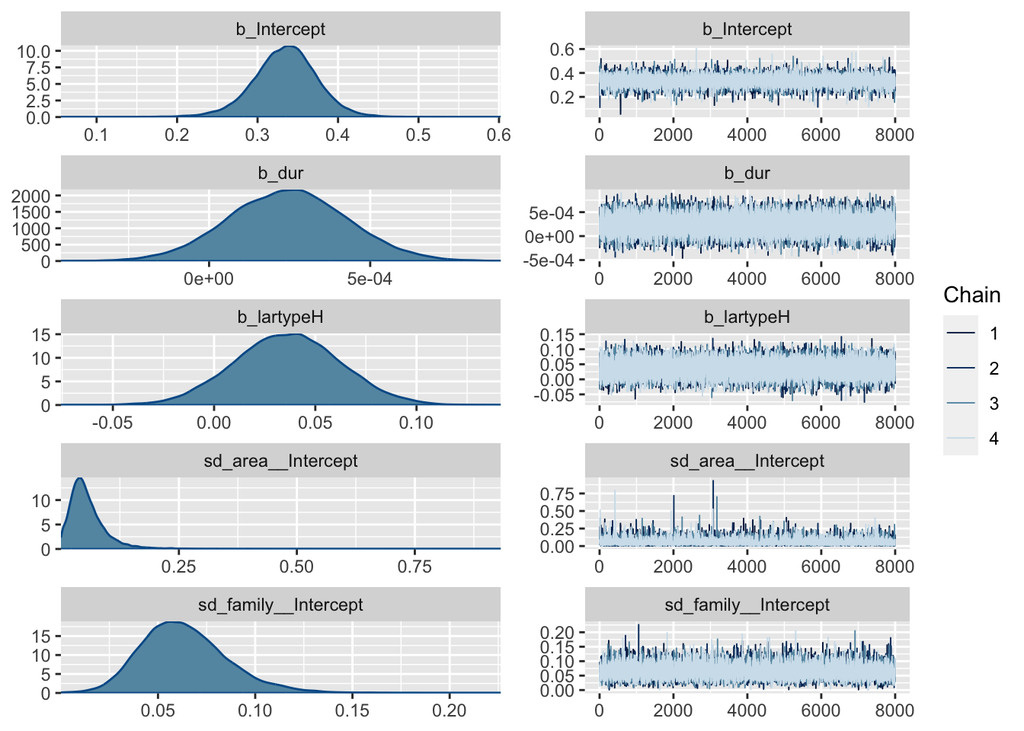

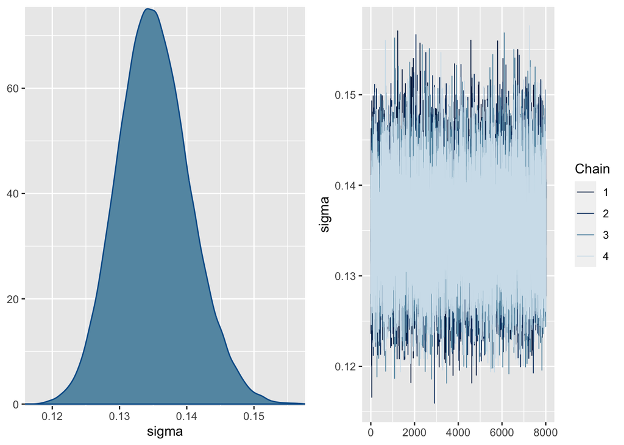

```r
plot(mod)
```

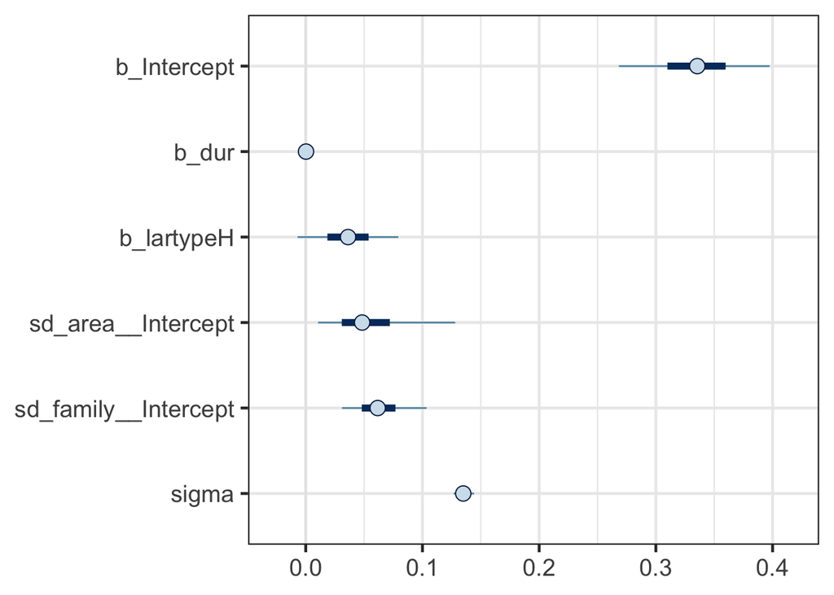

```r
mcmc_plot(mod)+theme_bw(base_size = 18)
```

### Posterior predictive check

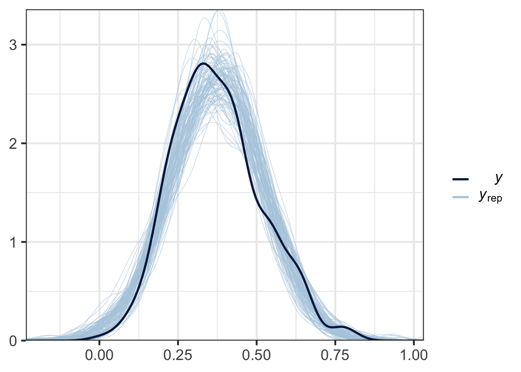

```r
# Posterior predictive check:
pp_check(mod, ndraws=100, type='dens_overlay')+theme_bw(base_size = 18)
```

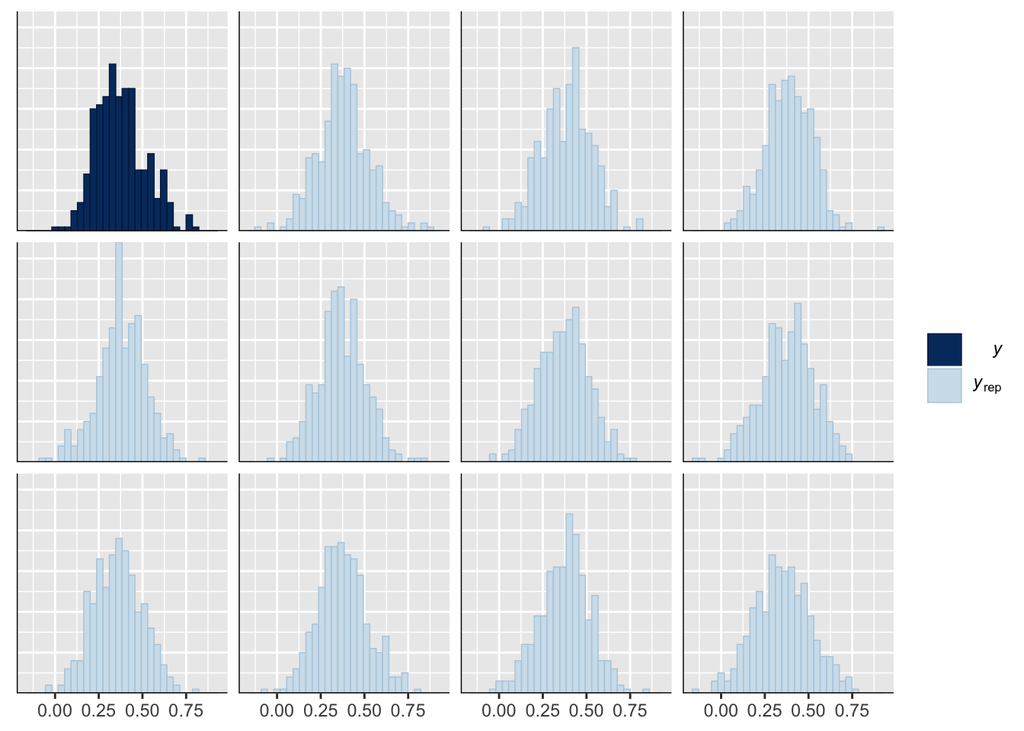

```r
pp_check(mod, ndraws=11, type='hist')
```

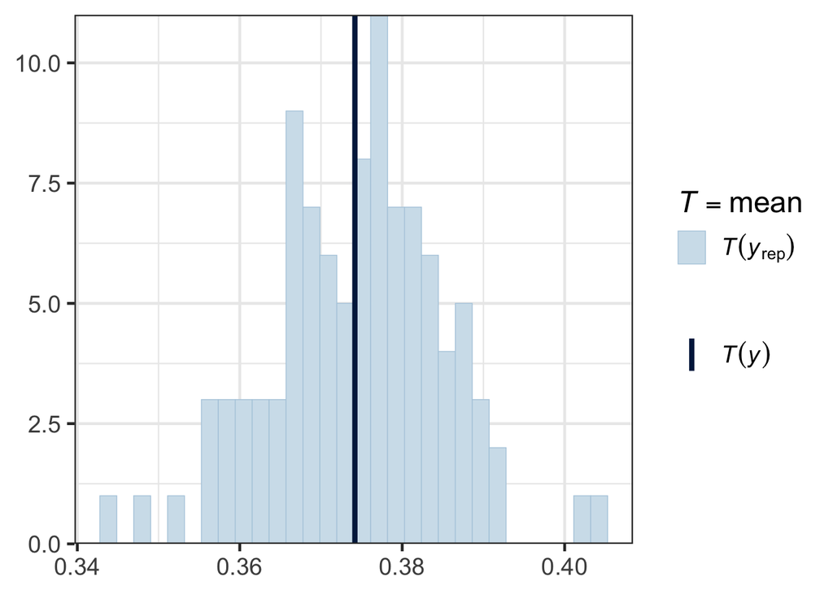

```r
# Plot posterior predictive distribution of statistical summaries:
pp_check(mod, ndraws = 100, type = "stat", stat = "mean")+theme_bw(base_size = 18)
```

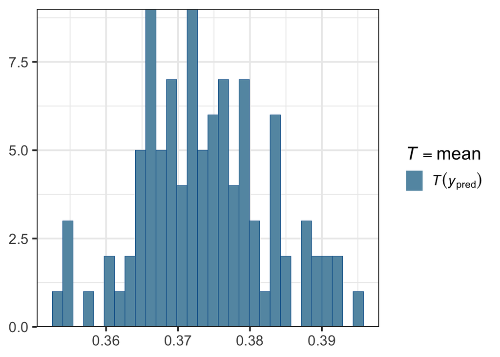

```r
# Plot prior predictive distribution of statistical summaries:
pp_check(mod, ndraws = 100, type = "stat", stat = "mean",
         prefix = "ppd")+theme_bw(base_size = 18)
```

### Calculate Bayes factor

```r
priors_weak0 <- c(
  # prior for the Intercept (= the reference level)
  prior(normal(0.2, 1), class = Intercept),
  # prior for the residual variance
  prior(cauchy(0, 0.1), class = sigma)
)

set.seed(62938)

mod0 <- brm(formula=norm.soe~dur+(1|family)+(1|area),data=df,
               family = gaussian(), prior = priors_weak0,
               save_pars = save_pars(all = T),
               iter=10000,warmup=2000,
               control = list(adapt_delta = 0.999)) # for higher flexibility & treedepth
options("mc.cores" = 5)

bayes_factor(
    x1 = mod,
    x2 = mod0,
    silent = TRUE,
    repetitions = 10,
    cores = getOption("mc.cores")
)
```

```
## Estimated Bayes factor (based on medians of log marginal likelihood estimates)
##  in favor of mod over mod0: 0.12752
## Range of estimates: 0.12119 to 0.13239
## Interquartile range: 0.00331
```

### Calculate 95% highest density interval for uncertainty

All points within this interval have a higher probability density than points outside the interval. The HDI can be used as Credible Interval (CI) to characterize uncertainty of posterior distributions.

```r
# 95% HDI
hdi(mod)
```

```
## Highest Density Interval
##
## Parameter   |       95% HDI
## ---------------------------
## (Intercept) | [ 0.25, 0.41]
## dur         | [ 0.00, 0.00]
## lartypeH    | [-0.01, 0.09]
```

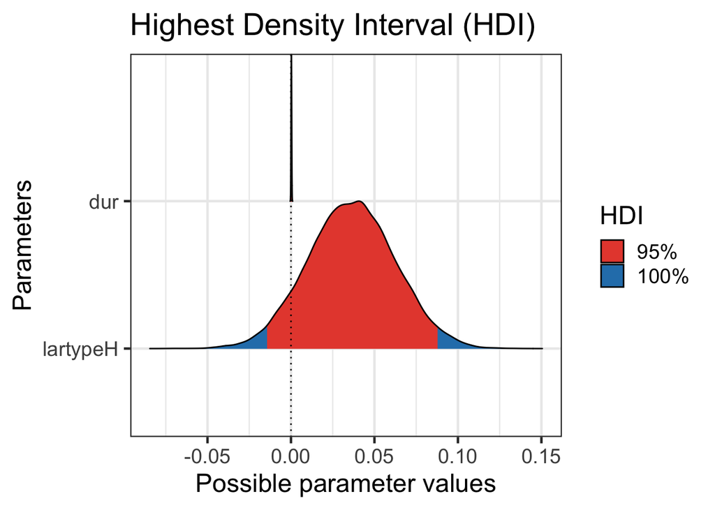

```r
plot(hdi(mod))+theme_bw(base_size = 18)
```

### Calculate probability of direction (pd) for effect existence

Pd can be interpreted as the probability (expressed in percentage) that a parameter (described by its posterior distribution) is strictly positive or negative (whichever is the most probable). It is mathematically defined as the proportion of the posterior distribution that is of the median’s sign. Although differently expressed, this index is fairly similar (i.e., is strongly correlated) to the frequentist p-value.

```r
# probability of direction
p_direction(mod)
```

```
## Probability of Direction
##
## Parameter   |     pd
## --------------------
## (Intercept) |   100%
## dur         | 90.99%
## lartypeH    | 91.50%
```

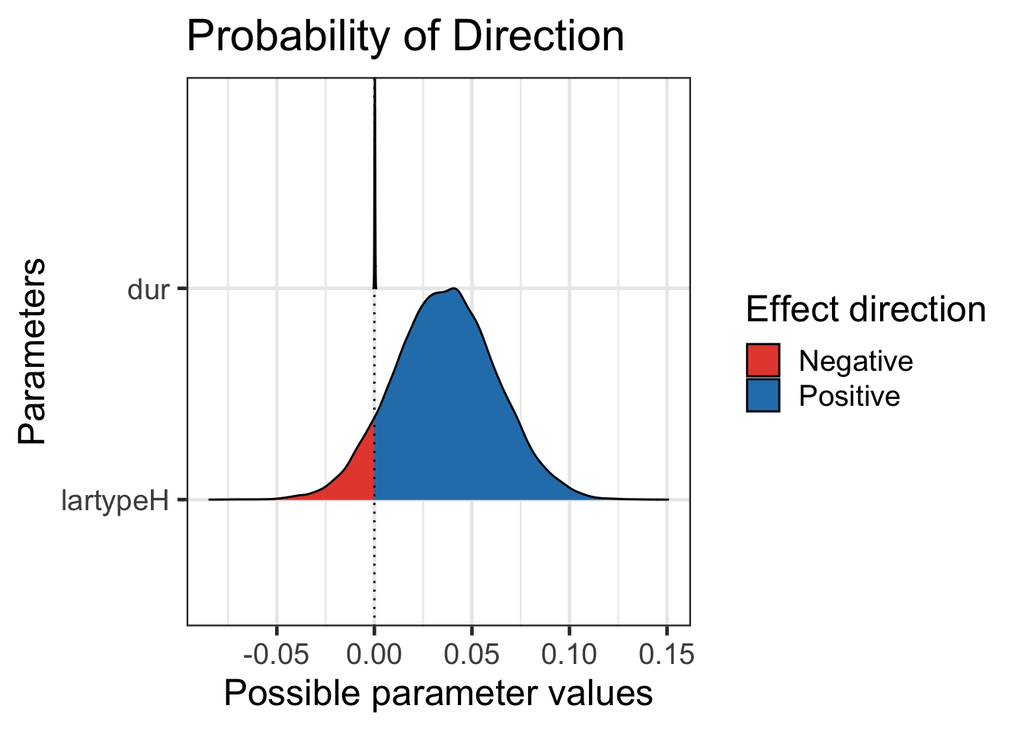

```r
plot(p_direction(mod))+theme_bw(base_size = 18)
```

```r
# convert to p-value in corresponding lmer model
pd_to_p(pd = p_direction(mod)$pd[3])
```

```
## [1] 0.17
```

### Calculate Region of Practical Equivalence (ROPE) for effect significance

ROPE is a region corresponding to a “null” hypothesis. Rather than concluding that an effect is present when it simply differs from zero, we would conclude that the probability of being outside a specific range (ROPE) that can be considered as “practically no effect” (i.e., a negligible magnitude) is sufficient.

```r
rope(mod)
```

```
## # Proportion of samples inside the ROPE [-0.01, 0.01]:
##
## Parameter | inside ROPE
## -----------------------
## Intercept |      0.00 %
## dur       |    100.00 %
## lartypeH  |     18.25 %
```

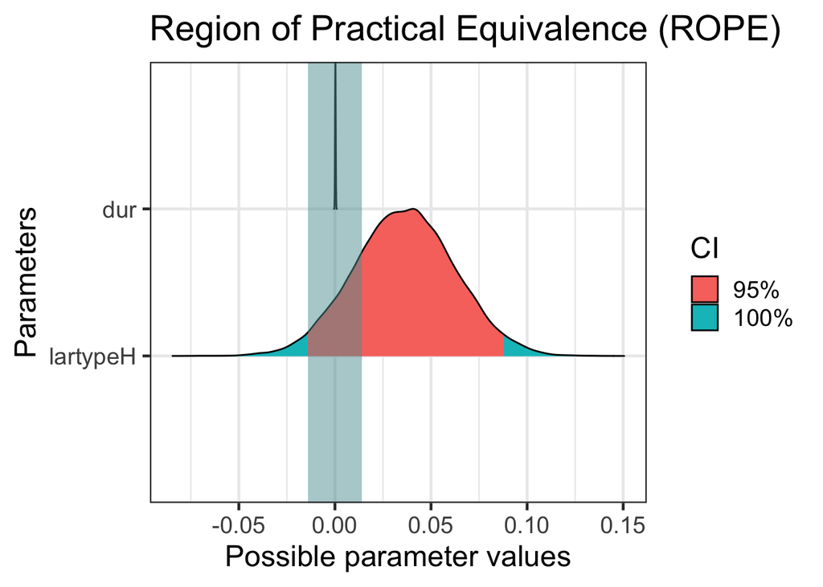

```r
plot(rope(mod))+theme_bw(base_size = 18)
```